# IBS 519 Homework 3 Revision Report

Firstname Lastname

2022-09-07

## Data cleaning - dimensional measurements

Previously in class, we reviewed the 3 dimensional measurements of the abalones. We know from the documentation provided at the data source at https://archive.ics.uci.edu/ml/datasets/abalone, that length should be the longest dimension and should be > height and > diameter.

This code will list the id’s of the abalones with any issues - including any with illogical values (such as height = 0).

### Summary Statistics of dimensional measurements

In the summary stats reported below, you’ll notice there are some abalones with height = 0.

```r
# code from in class examples
abalone %>%
  select(length, diameter, height) %>%
  summary()
```

|  | length | diameter | height |
| --- | --- | --- | --- |
|  | Min. :0.075 | Min. :0.0550 | Min. :0.0000 |
|  | 1st Qu.:0.450 | 1st Qu.:0.3500 | 1st Qu.:0.1150 |
|  | Median :0.545 | Median :0.4250 | Median :0.1400 |
|  | Mean :0.524 | Mean :0.4079 | Mean :0.1395 |
|  | 3rd Qu.:0.615 | 3rd Qu.:0.4800 | 3rd Qu.:0.1650 |
|  | Max. :0.815 | Max. :0.6500 | Max. :1.1300 |

### Identify the abalones with height = 0

```r
abalone %>%
  filter(height == 0) %>%
  select(id, length, diameter, height)
```

| id | length | diameter | height |
| --- | --- | --- | --- |
| 1258 | 0.430 | 0.34 | 0 |
| 3997 | 0.315 | 0.23 | 0 |

### Identify the abalones with height > length

```r
abalone %>%
  filter(height > length) %>%
  select(id, length, diameter, height)
```

| id | length | diameter | height |
| --- | --- | --- | --- |
| 2052 | 0.455 | 0.355 | 1.13 |

### Identify the abalones with diameter > length

```r
abalone %>%
  filter(diameter > length) %>%
  select(id, length, diameter, height)
```

| id | length | diameter | height |
| --- | --- | --- | --- |
| 1211 | 0.185 | 0.375 | 0.12 |

### Visualize the abalone with height > length

From the plot below, we can see any abalones above the reference line that have height > length and using color for each sex, we can also note which sex has this illogical measurement.

The abalone with height > length is a F, female.

There is also a M, male, with a large height relative to its length (even though its height is < its length), and it’s height is quite a bit larger than the other abalone heights.

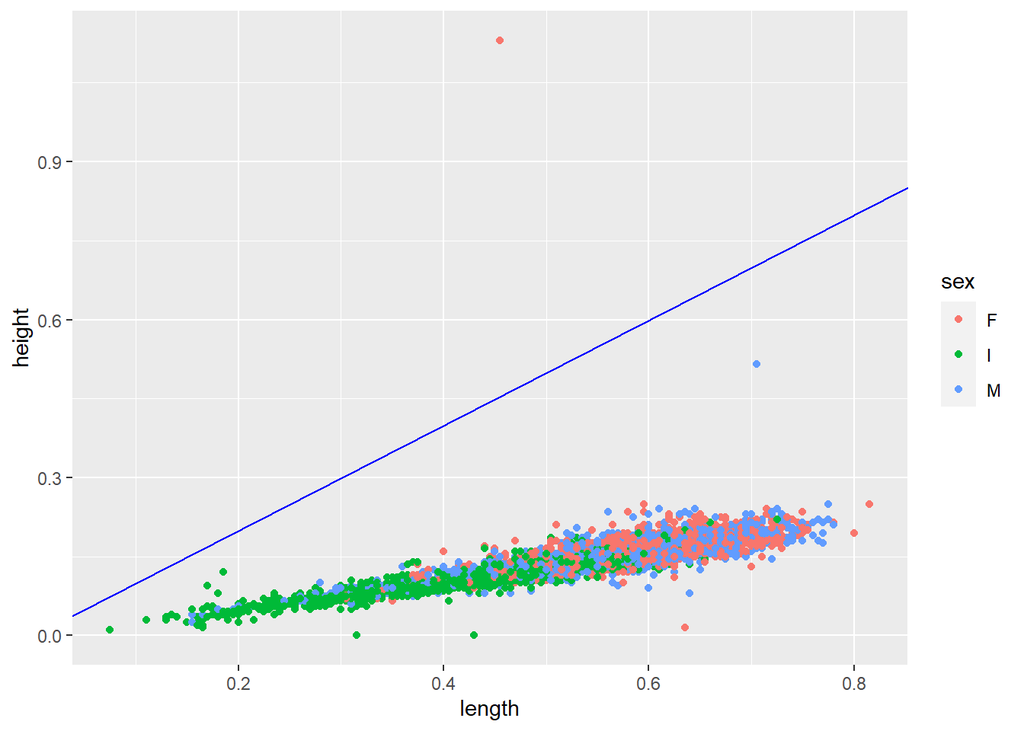

```r
ggplot(abalone, aes(length, height)) +
  geom_point(aes(color = sex)) +
  geom_abline(intercept = 0,
              slope = 1,
              color = "blue")
```